# Support Vector Machine Modeling of Transcription Factor Binding Sites

Brady Nifong, Mike Nodzenski, Fan Zhou

## Introduction

### Background

Despite rapid improvements in high throughput sequencing technologies, the functional significance of much of the human genome remains unclear. While protein coding regions have been well characterized, the majority of bases do not fall into this category. The ongoing Encyclopedia of DNA Elements (ENCODE) Project (1) seeks to address this issue. A key goal of the project is to more fully describe the mechanisms of gene transcription. A variety of techniques are used in the projects including but not limited to CHIP-seq (transcription factor binding) and DNAse-seq (open chromatin). Our project will focus on CHIP-seq data from ENCODE.

### Motivating Study

> Arvey A, Agius P, Noble WS, Leslie C. Sequence and chromatin determinants of cell-type-specific transcription factor binding. Genome Res. 2012 Sep;22(9):1723-34.

The aim of the study described in Arvey et al. was to predict cell type specific transcription factor (TF) binding using publicly available ENCODE data. Traditionally, this is done using motif finding algorithms to identify high affinity sequence for a particular protein. Arvey et al. argued support vector machine modeling (SVM) of TF binding more accurately predicts binding sites than traditional approaches. The authors analyzed TF factor binding data for 286 CHIP-seq experiments of 67 transcriptional regulators using Kmer SVM and three motif finding approaches: MDScan, cERMIT, WeederK1. They developed a string kernel specifically tailored to these types of sequence data when applying Kmer SVM models and ultimately found that this approach more accurately predicted TF binding than motif finding as assessed by area on the curve. They further investigated whether open chromatin and histone modifications played a role in cell specific TF binding and found that open chromatin was a strong predictor of cell-specific binding.

### Our Aims

Given the time and resource limitations of this project, it was not possible to completely reproduce all results in Arvey et al. since their analysis contained 286 experiments. Moreover, we also could not reproduce their motif finding results because they algorithms they implemented are not currently available through Bioconductor. Therefore, we simplified their study design and sought to use SVM to accurately predict transcription factor binding in a subset of the cell lines and proteins investigated in the paper.

## Methods

### Experiment Selection

We queried AnnotationHub for CHIP-seq data seven proteins PAX5, REST, USF1, MAX, JUND, YY1, GABPA, which are mentioned in Arvey et al.. Since our goal was to choose proteins with experimental data across multiple cell lines, based on the available data we eventually selected three proteins: JUND, MAX, USF1 with experimental data across four cell lines: H1hesc, Hepg2, GM12878, K562.

```r
#prelimnary investigation of available data
library(rtracklayer)
library(AnnotationHub)
library(SummarizedExperiment)
#ah <- AnnotationHub()

#look at available chipseq data for proteins from the paper
#pax5.experiments <- query(ah, c("PAX5", "Tfbs", "UniPk"))
#rest.experiments <- query(ah, c("REST", "Tfbs", "UniPk"))
#usf1.experiments <- query(ah, c("USF1", "Tfbs", "UniPk"))
#max.experiments <- query(ah, c("MAX", "Tfbs", "UniPk"))
#jund.experiments <- query(ah, c("JUND", "Tfbs", "UniPk"))
#yy1.experiments <- query(ah, c("YY1", "Tfbs", "UniPk"))
#gabpa.experiments <- query(ah, c("GABPA", "Tfbs", "UniPk"))

#most complete options are JUND, MAX, USF1, in H1hesc, Hepg2, GM12878, K562
```

### Data Processing

Following the methods of Arvey et al, we applied a three-step processing procedure to the data for all cell line/protein combinations:

1. Selected the top 1000 CHIP-seq peaks by signal value.
2. Extracted sequence for 100 bp region from each selected peak as a positive binding example.
3. Used flanking 100-bp regions sampled 200 bp away as non-binding examples.

```r
##writing functions to process and run svm on binding sites for proteins and
##cell lines referenced above


#1. function to pull summarized experiment for cell line a protein
get.exp <- function(cell.line, protein){

  cell.protein.query <- query(ah, c(cell.line, protein, "Tfbs", "UniPk"))
  if (length(cell.protein.query) == 0){

    print(paste("No matches for", paste(cell.line, protein)))

  }
  if( length(cell.protein.query) > 0){

    query(ah, c(cell.line, protein,"Tfbs", "UniPk"))[[1]]

  }
}

library("BSgenome.Hsapiens.UCSC.hg19")

#2. function to extract dna stringset from summarized experiment
extract.seq <- function(exp.data, subset = TRUE){

  if (subset){

    #make widths of sequence the same
    #per paper, use 100 bp

    #first subset out small peaks
    target.peaks <- exp.data[width(exp.data) > 100, ]

    #get the middle of ranges with more than 100 peaks
    exp.data <- target.peaks - round((width(target.peaks) - 100)/2)
    exp.data <- resize(exp.data, 100)

  }

  #extract sequences
  seqs <- getSeq(Hsapiens, exp.data)
  return(seqs)

}


#3. function that combines previous two functions to pull down
#data for a single cell line and protein
#and put it together into a useable dna stringset and vector
#of binding site vs non-binding predictions

format.exp.data <- function(protein, cell.line){

     #pull down data for protein and cell line
    exp.data <- get.exp(protein, cell.line)

    #subset to top 1000 of 100 bp per paper instructions
    top.peaks <- exp.data[width(exp.data) > 100, ]
    top.peaks <- top.peaks[order(-top.peaks$signalValue), ]
    top.peaks <- top.peaks[1:1000, ]

    #get 100 bp flanking regions sampled 200 bp away
    flank.regions <- flank(top.peaks + 200, 100)

    #extract sequence for target peaks and flanks
    binding.seqs <- extract.seq(top.peaks)
    non.binding.seqs <- extract.seq(flank.regions, subset = F)

    #concatenate
    combined.seqs <- c(binding.seqs, non.binding.seqs)

    #make vector of binding site classification
    #1 for tf binding, -1 for non-binding
    tf.binding <- c(rep(1, length(binding.seqs)), rep(-1, length(non.binding.seqs)))

    #return string set and tf.binding vector
    return(list(sequences = combined.seqs, tf.binding = tf.binding))

}
```

### Support Vector Machine Modeling

We initially ran models individually on specific cell line/protein combinations using the SVM function implemented in the Kebabs Bioconductor package to predict binding status using DNA sequence. Specifically, we sampled 70% of extracted sequences as training data and the remaining 30% formed the testing set to validate the prediction accuracy of the trained model. Unfortunately, the string kernel from Arvey et al. is not available through Bioconductor or CRAN. Instead, we substituted a similar mismatch kernel from the Kebabs package, which was introduced by the same research group, with tuning parameters k and m set to 8 and 2, respectively. We also ran models for protein binding pooling data across cell lines using the same approach to assess whether combining data improved prediction.

### Assessing SVM Accuracy

We assessed SVM accuracy in two ways. First, we identified the most predictive kmer from each model as the sequence with the largest absolute feature weight, and compared this to known protein binding motifs from the JASPAR database. In doing so, we hoped established the biological plausibility of our results. Second, we used the AUC (Area under the curve) of each SVM on the testing data to assess model accuracy. This was the primary performance measurement in Arvey et al., and while it is not as biologically interpretable as comparison to known motifs, it is a useful secondary indicator of predictive ability.

```r
##Actually run the above functions on target proteins and cells

#specify target proteins and cells
target.proteins <- rep(c("JUND", "MAX", "USF1"), each = 4)
target.cells <- rep(c("H1HESC", "HEPG2", "GM12878", "K562"), 3)

#pull in data
#note that this only works reasonably quickly by running jobs in parallel
#on MN's computer (4 core)

#As a consequence, so this will compile on the computers of all
#group members, the parallel code that was used by MN to produce the results
#(below) is commented out and saved results objects are loaded into the workspace
#instead. To be absolutely clear, the commented out code actually produced the
#results for this markdown.

################################
##code used to produce results
################################

###read in and format target cell/protein data

##first for individual cells

#library(BiocParallel)
#param <- bpparam()
#bpworkers(param) <- 5
#exp.data.list <- bpmapply(format.exp.data, target.proteins, target.cells, BPPARAM = param, SIMPLIFY = F)

#name the elements of the list
#names(exp.data.list) <- paste(target.proteins, target.cells)

##then combining acorss cell types

##make another list by combining protein data across cell types
#combined.cell.data.list <- lapply(unique(target.proteins), function(protein){
#
#  protein.cell.data <- exp.data.list[grep(protein, names(exp.data.list))]
#  combined.cell.data <- Reduce(function(...) mapply(c, ...), protein.cell.data)
#  return(combined.cell.data)
#
#})
#names(combined.cell.data.list) <- unique(target.proteins)

#instead loading saved object produced by MN using the above commands
library("RCurl")
download.file("https://github.com/bradysnifong/Group-6-Final/blob/master/group6.results.RDA?raw=true", "project.data")
load("group6.results.rda")
```

```r
##Now writing functions to run svm to predict TF binding

run.svm <- function(combined.seqs, tf.binding){

  #set kernel
  #this is not the precise kernel used in the paper
  #but seems similar, is avaialable in this package, and is from the same
  #author of the paper

  #note: using k = 8 and and m = 2 per paper
  mismatch.kern <- mismatchKernel(k=8,m=2)

  #get training and test data
  n.samples <- length(tf.binding)
  training.obs <-sample(1:n.samples, 0.7*n.samples)
  test.obs <-c(1:n.samples)[-training.obs]

  #run svm on training data
  exrep<-getExRep(combined.seqs, mismatch.kern, sparse=FALSE)
  svm.model <- kbsvm(x = exrep[training.obs, ], y = tf.binding[training.obs], kernel = mismatch.kern)

  #pull out feature weights
  fw <- svm.model@featureWeights
  names(fw) <- svm.model@trainingFeatures

  #look at accuracy
  pred.profile <- predict(svm.model, combined.seqs[test.obs], predProfiles = T)
  svm.predictions <- predict( svm.model, exrep[test.obs, ])
  svm.decisions <- predict(svm.model, exrep[test.obs, ], predictionType = "decision")
  eval.data <- evaluatePrediction( svm.predictions, tf.binding[test.obs], allLabels = unique(tf.binding), decValues = svm.decisions, print = F)

  #get auc
  rocdata<-computeROCandAUC(svm.decisions, tf.binding[test.obs], unique(tf.binding))
  return(list(rocdata = rocdata, pred.profile = pred.profile, eval.data = eval.data, fw = fw))

}
```

```r
##Now actually run svm on the target cell lines and proteins

##As above, this requires paralllel processing, with only works on MN's computer
##Therefore, these commands are commented out, so the rmd will compile for
##all group members, but the code that produced the results is still clear

##further note that these results objects were read into the workspace along
##with the processed experimental data in the download.file command above

library(kebabs)

################################################################
##first run svm to predict binding for cell-line specific data
##################################################################

#svm.indiv.cell <- bplapply(exp.data.list, function(cell.protein.data){

#    run.svm(cell.protein.data$sequences, cell.protein.data$tf.binding)

#}, BPPARAM = param)
#names(svm.indiv.cell) <- names(exp.data.list)

##########################################################
#then run for each target protein combing data across cell
#lines
###########################################################

#svm.combined.cell <- bplapply(combined.cell.data.list, function(comb.cell.data){

#    run.svm(comb.cell.data$sequences, comb.cell.data$tf.binding)

#}, BPPARAM = param)

#names(svm.combined.cell) <- names(combined.cell.data.list)


#save relevant objects
#save(list = c('svm.indiv.cell', 'svm.combined.cell', 'exp.data.list', 'combined.cell.data.list'), file = "group6.results.RDA")
```

```r
###commamnds to examine results of svm

#first, grab the most predictive kmer from each svm model,
#where 'most predictive' is defined as the kmer with the highest feature weight,
#and compare to known binding motifs

best.kmers <- sapply(svm.indiv.cell, function(cell.protein){

  #grab results
  fw <- cell.protein$fw

  #most predictive kmer
  top.kmer <- names(fw)[fw == max(abs(fw))]
  return(top.kmer)

})
names(best.kmers) <- names(svm.indiv.cell)

#using the best.kmers results, figures were manually created for presentation

##pull in manually created figures
```

## Results

### Comparison to JASPAR Motifs

The following figures display JASPAR Motifs (top) and the the most predictive kmer (bottom) for each cell-line/transcription factor combination. Across cell lines, USF1 has the highest consistency with JASPAR motifs compared to the other two proteins. However, the most predictive kmers for all three proteins were fairly close to the motifs, suggesting SVM is an accurate predictive approach. We also note that JASPAR motifs are not the definitive word on protein binding, so the mismatching bases are not necessarily indicative of inaccurate prediction.

#### JUND:

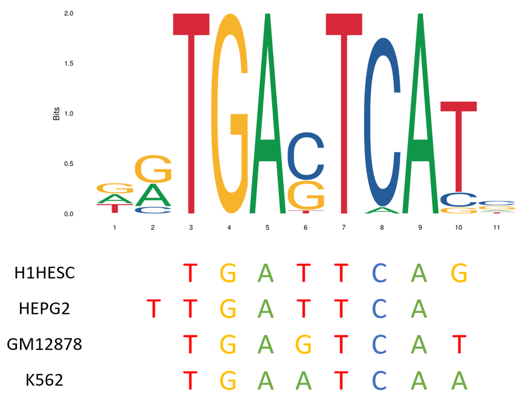

#### MAX

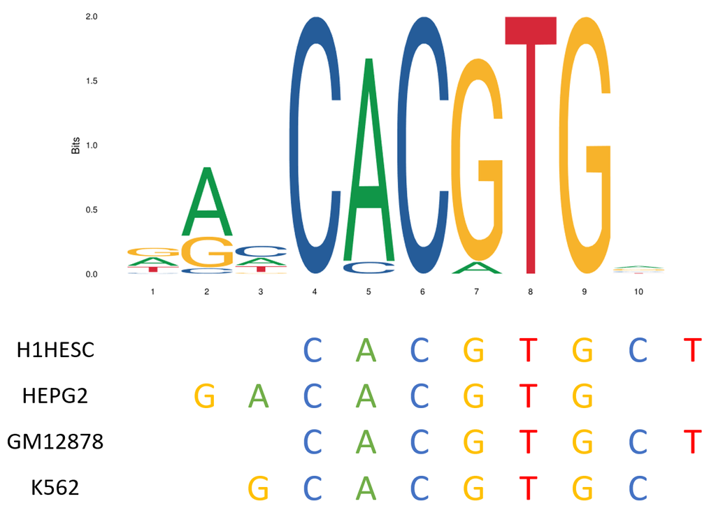

#### USF1

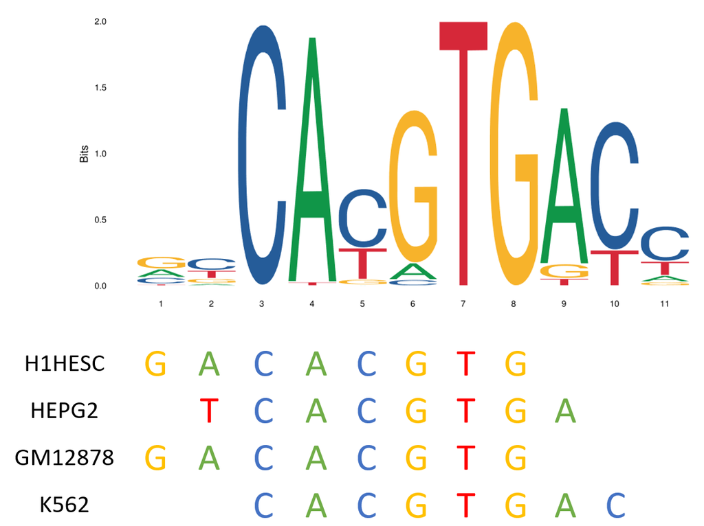

### Examination of Feature Weights

The following three plots display the distribution of feature weights for each fitted svm. All histograms are unimodal and centered tightly around zero. Though we cannot directly compare the three histograms, the majority of features for each predictive model provide little information towards predicting binding sites.

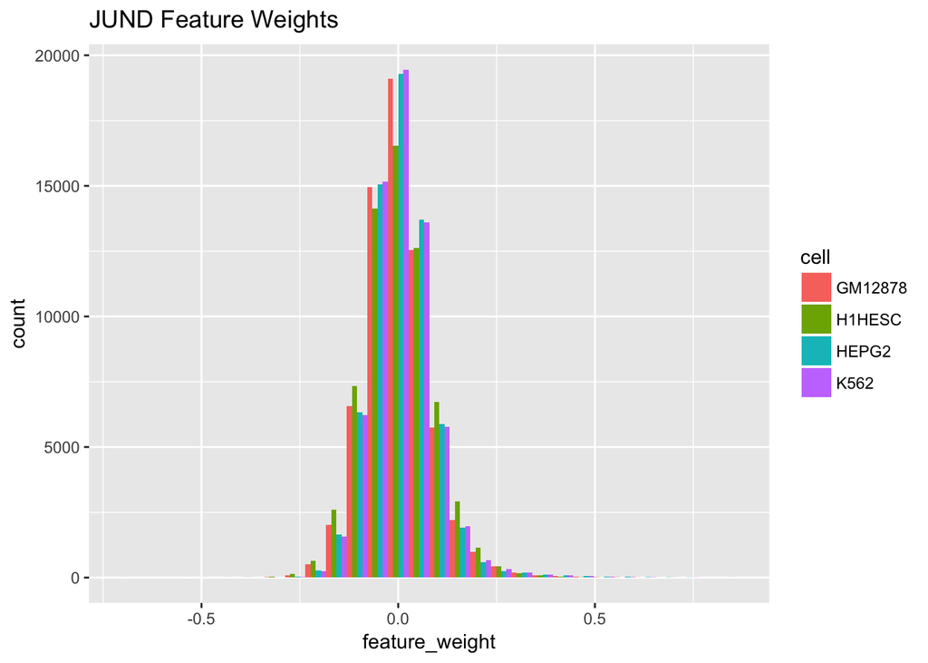

```r
##Now put together histograms of feature weights for each protein and cell line

#function to pull together feature weight data for a specified protein across all 4 cell lines
fw.df <-function(protein){

  target.results <- svm.indiv.cell[grep(protein, names(svm.indiv.cell))]
  cell.names <- gsub(paste0(protein, " "), "", names(svm.indiv.cell)[grep(protein, names(svm.indiv.cell))])
  fw.lengths <- sapply(target.results, function(x) length(x$fw))
  stopifnot(length(unique(fw.lengths)) == 1)
  cell.names <- rep(cell.names, each = unique(fw.lengths))
  combined <- Reduce(function(...) mapply(c, ...), target.results)
  plot.df <- data.frame(protein = protein, cell = cell.names, feature_weight = combined$fw)
  return(plot.df)

}

jund.fw.data <- fw.df("JUND")
max.fw.data <- fw.df("MAX")
usf1.fw.data <- fw.df("USF1")

#plot feature weight histograms
library(ggplot2)
ggplot(jund.fw.data, aes(x = feature_weight, fill = cell)) + geom_histogram(position = "dodge") + ggtitle("JUND Feature Weights")
```

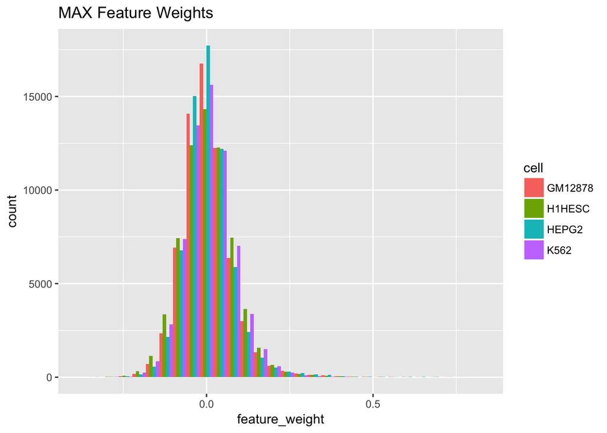

```r
ggplot(max.fw.data, aes(x = feature_weight, fill = cell)) + geom_histogram(position = "dodge") + ggtitle("MAX Feature Weights")
```

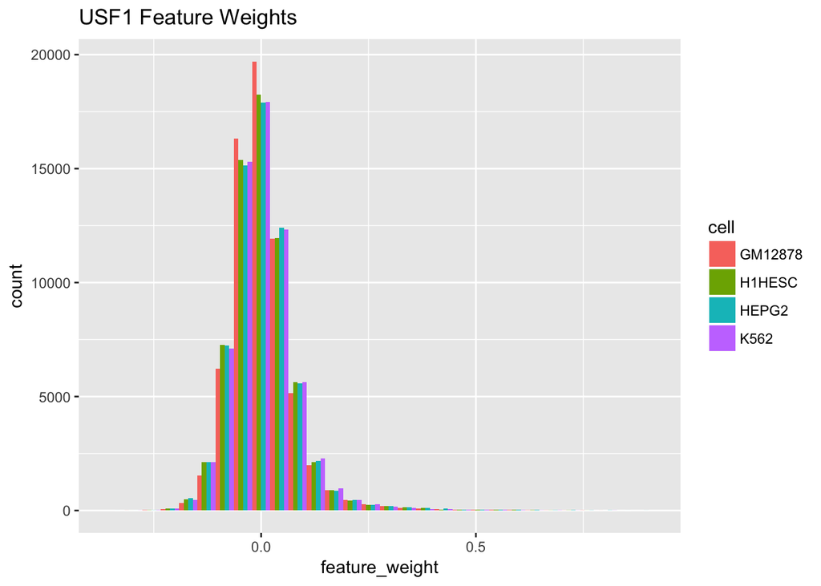

```r
ggplot(usf1.fw.data, aes(x = feature_weight, fill = cell)) + geom_histogram(position = "dodge") + ggtitle("USF1 Feature Weights")
```

### Area Under the Curve (AUC)

We plotted the sensitivity vs false positive rate and gave the AUC for each cell specific model, as well as pooling the data across cell-lines.

#### Cell specific models:

In general, we predicted USF1 binding most accurately. These models had the best AUC across cell lines. Models were also very accurate for JUND and MAX, though there was more variability across cell lines. AUC was higher for JUND than MAX in some cell lines, but lower in others.

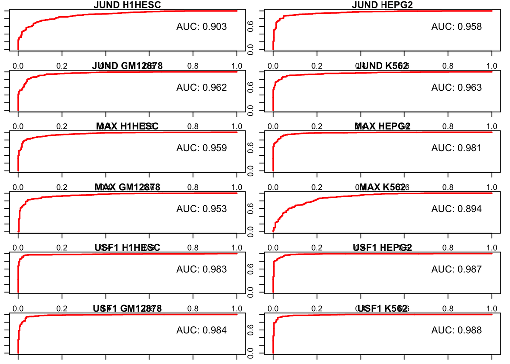

```r
##last, plot ROC curves
##perhaps not the most interesting figures, but AUC was a major source of emphasis
##for the soure paper

#first, plot ROC curves for cell-lines individually
par(mar=c(1,1,1,1))
par(mfrow = c(6,2))
invisible(lapply(names(svm.indiv.cell), function(protein.cell){

  plot.data <- svm.indiv.cell[[protein.cell]]
  plot(plot.data$rocdata, main = protein.cell ,col="red",lwd=2)

}))
```

#### Models pooling data across cell-lines

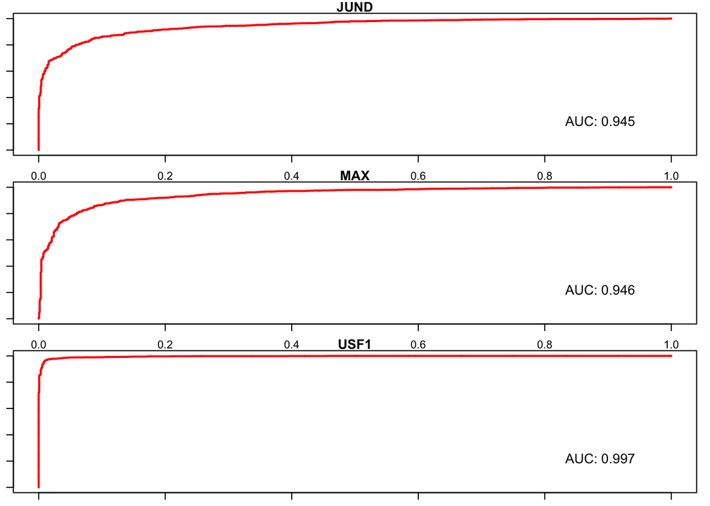

```r
#Then plot for svm results run on combined cell-line results
par(mar=c(1,1,1,1))
par(mfrow = c(3,1))
invisible(lapply(names(svm.combined.cell), function(protein){

  plot.data <- svm.combined.cell[[protein]]
  plot(plot.data$rocdata, main = protein ,col="red",lwd=2)

}))
```

## Discussion

SVM modeling very accurately predicted transcription factor binding in a subset of the proteins and cell lines from Arvey et al.. AUC values were above 89% for all cell-line specif models and above 94% for models pooling data across cell lines. Similar to Arvey et al., we found that some proteins are easier to predict than others. For example, we predicted USF1 binding more accurately than JUND and MAX, both within and across cell-lines, as indicated by higher AUC values. Also similar to Arvey, we saw variation in predictive ability among cell-lines within the same protein. For instance, predictions of JUND binding in K652 were more accurate than in H1hesc. Conversely, predictions for MAX were more accurate in H1hesc than K652. These findings indicate that there may be other factors influencing cell specific binding. Arvey et al. suggest this may be open chromatin.

Our project has limitations. We could not directly reproduce the results in Arvey et al. because we focused on a small subset of their data. We also used a different kernel for SVM modeling. Furthermore, we were unable to assess the predictive value of open chromatin on transcription factor binding since the SVM implemented in Kebabs does not allow for covariates. Nevertheless, we conclude that support vector machine modeling achieves an acceptable prediction accuracy and may be a useful tool in predicting the binding sites of proteins with unknown motifs.

## References

1. The ENCODE Project Consortium. An Integrated Encyclopedia of DNA Elements in the Human Genome. Nature. 2012;489(7414):57-74. doi:10.1038/nature11247.